# Introduction to cito

Christian Amesoeder & Maximilian Pichler

2023-09-23

Abstract

‘cito’ allows you to build and train neural networks using the R formula syntax. It relies on the ‘torch’ package for numerical computations and optional graphic card support.

## Setup - Installing torch

Before using ‘cito’ make sure that the current version of ‘torch’ is installed and running.

```r
if(!require(torch)) install.packages("torch")
library(torch)
if(!torch_is_installed()) install_torch()

library (cito)
```

If you have problems installing Torch, check out the [installation help from the torch developer](https://torch.mlverse.org/docs/articles/installation.html).

## Introduction to models and model structures

### Loss functions / Likelihoods

Cito can handle many different response types. Common loss functions from ML but also likelihoods for statistical models are supported:

| Name | Explanation | Example / Task | Meta-Code |
| --- | --- | --- | --- |
| `mse` | mean squared error | Regression, predicting continuous values | `dnn(Sepal.Length~., ..., loss = "mse")` |
| `mae` | mean absolute error | Regression, predicting continuous values | `dnn(Sepal.Length~., ..., loss = "msa")` |
| `softmax` | categorical cross entropy | Multi-class, species classification | `dnn(Species~., ..., loss = "softmax")` |
| `cross-entropy` | categorical cross entropy | Multi-class, species classification | `dnn(Species~., ..., loss = "cross-entropy")` |
| `gaussian` | Normal likelihood | Regression, residual error is also estimated (similar to `stats::lm()`) | `dnn(Sepal.Length~., ..., loss = "gaussian")` |
| `binomial` | Binomial likelihood | Classification/Logistic regression, mortality (0/1 data) | `dnn(Presence~., ..., loss = "Binomial")` |
| `poisson` | Poisson likelihood | Regression, count data, e.g. species abundances | `dnn(Abundance~., ..., loss = "Poisson")` |

Moreover, all non multilabel losses (all except for softmax or cross-entropy) can be modeled as multilabel using the cbind syntax

`dnn(cbind(Sepal.Length, Sepal.Width)~., …, loss = "mse")`

The likelihoods (Gaussian, Binomial, and Poisson) can be also passed as their stats equivalents:

`dnn(Sepal.Length~., ..., loss = stats::gaussian)`

### Data

In this vignette, we will work with the irirs dataset and build a regression model.

```r
data <- datasets::iris
head(data)
```

```
#>   Sepal.Length Sepal.Width Petal.Length Petal.Width Species
#> 1          5.1         3.5          1.4         0.2  setosa
#> 2          4.9         3.0          1.4         0.2  setosa
#> 3          4.7         3.2          1.3         0.2  setosa
#> 4          4.6         3.1          1.5         0.2  setosa
#> 5          5.0         3.6          1.4         0.2  setosa
#> 6          5.4         3.9          1.7         0.4  setosa
```

```r
#scale dataset
data <- data.frame(scale(data[,-5]),Species = data[,5])
```

### Fitting a simple model

In ‘cito’, neural networks are specified and fitted with the `dnn()` function. Models can also be trained on the GPU by setting `device = "cuda"`(but only if you have installed the CUDA dependencies). This is suggested if you are working with large data sets or networks.

```r
library(cito)

#fitting a regression model to predict Sepal.Length
nn.fit <- dnn(Sepal.Length~. , data = data, epochs = 12, loss = "mse", verbose=FALSE)
```

You can plot the network structure to give you a visual feedback of the created object. e aware that this may take some time for large networks.

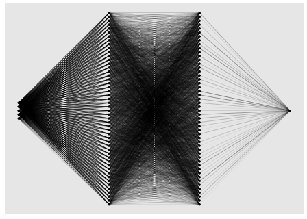

```r
plot(nn.fit)
```

The neural network 5 input nodes (3 continoues features, Sepal.Width, Petal.Length, Petal.Width and the contrasts for the Species variable (n_classes - 1)) and 1 output node for the response (Sepal.Length).

### Baseline loss

At the start of the training we calculate a baseline loss for an an intercept only model. It allows us to control the training because the goal is to beat the baseline loss. If we don’t, we need to adjust the optimization parameters (epochs and lr (learning rate)):

```r
nn.fit <- dnn(Sepal.Length~. , data = data, epochs = 50, lr = 0.6, loss = "mse", verbose = FALSE) # lr too high
```

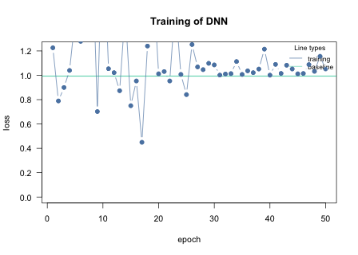

vs

```r
nn.fit <- dnn(Sepal.Length~. , data = data, epochs = 50, lr = 0.01, loss = "mse", verbose = FALSE)
```

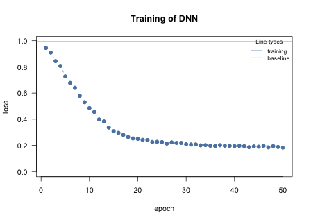

See `vignette("B-Training_neural_networks"`) for more details on how to adjust the optimization procedure and increase the probability of convergence.

### Adding a validation set to the training process

In order to see where your model might suffer from overfitting the addition of a validation set can be useful. With `dnn()` you can put `validation = 0.x` and define a percentage that will not be used for training and only for validation after each epoch. During training, a loss plot will show you how the two losses behave (see `vignette("B-Training_neural_networks"`) for details on training NN and guaranteeing their convergence).

```r
#20% of data set is used as validation set
nn.fit <- dnn(Sepal.Length~., data = data, epochs = 32,
              loss= "mse", validation = 0.2)
```

Weights oft the last and the epoch with the lowest validation loss are saved:

```r
length(nn.fit$weights)
```

```
#> [1] 2
```

The default is to use the weights of the last epoch. But we can also tell the model to use the weights with the lowest validation loss:

```r
nn.fit$use_model_epoch = 1 # Default, use last epoch
nn.fit$use_model_epoch = 2 # Use weights from epoch with lowest validation loss
```

### Methods

cito supports many of the well-known methods from other statistical packages:

```r
predict(nn.fit)
coef(nn.fit)
print(nn.fit)
```

## Explainable AI - Understanding your model

xAI can produce outputs that are similar to known outputs from statistical models:

| xAI Method | Explanation | Statistical equivalent |
| --- | --- | --- |
| Feature importance (returned by `summary(nn.fit)`) | Feature importance based on permutations. See Fisher, Rudin, and Dominici (2018) Similar to how much variance in the data is explained by the features. | `anova(model)` |
| Average conditional effects (ACE) (returned by `summary(nn.fit)`) | Average of local derivatives, approximation of linear effects. See [Pichler and Hartig (2023)](https://arxiv.org/abs/2306.10551) | `lm(Y~X)` |
| Standard Deviation of Conditional Effects (SDCE) (returned by `summary(nn.fit)`) | Standard deviation of the average conditional effects. Correlates with the non-linearity of the effects. |  |
| Partial dependency plots (`PDP(nn.fit)`) | Visualization of the response-effect curve. | `plot(allEffects(model))` |
| Accumulated local effect plots (`ALE(nn.fit)`) | Visualization of the response-effect curve. More robust against collinearity compared to PDPs | `plot(allEffects(model))` |

The `summary()` returns feature importance, ACE and SDCE:

```r
# Calculate and return feature importance
summary(nn.fit)
```

```
#> Summary of Deep Neural Network Model
#>
#> Feature Importance:
#>       variable importance_1
#> 1  Sepal.Width     1.074052
#> 2 Petal.Length     3.159223
#> 3  Petal.Width     1.679874
#> 4      Species     1.065916
#>
#> Average Conditional Effects:
#>              Response_1
#> Sepal.Width  0.05517015
#> Petal.Length 0.46260933
#> Petal.Width  0.18427827
#>
#> Standard Deviation of Conditional Effects:
#>              Response_1
#> Sepal.Width  0.05146226
#> Petal.Length 0.12890666
#> Petal.Width  0.06626894
```

```r
#returns weights of neural network
coef(nn.fit)
```

### Uncertainties/p-Values

We can use bootstrapping to obtain uncertainties for the xAI metrics (and also for the predictions). For that we have to retrain our model with enabled bootstrapping:

```r
df = data
df[,2:4] = scale(df[,2:4]) # scaling can help the NN to convergence faster
nn.fit <- dnn(Sepal.Length~., data = df,
              epochs = 100,
              verbose = FALSE,
              loss= "mse",
              bootstrap = 30L
              )
```

```r
summary(nn.fit)
```

```
#> Summary of Deep Neural Network Model
#>
#>  ##########################################################
#>      Feature Importance
#>  ##########################################################
#>                          Importance Std.Err Z value Pr(>|z|)
#> Response_1: Sepal.Width       1.169   0.405    2.89   0.0039 **
#> Response_1: Petal.Length      7.328   3.283    2.23   0.0256 *
#> Response_1: Petal.Width       0.988   0.636    1.55   0.1202
#> Response_1: Species           0.212   0.120    1.77   0.0771 .
#> ---
#> Signif. codes:  0 '***' 0.001 '**' 0.01 '*' 0.05 '.' 0.1 ' ' 1
#>
#>
#>  ##########################################################
#>      Average Conditional Effects
#>  ##########################################################
#>                             ACE Std.Err Z value Pr(>|z|)
#> Response_1: Sepal.Width  0.2975  0.0651    4.57  4.9e-06 ***
#> Response_1: Petal.Length 0.7365  0.1462    5.04  4.8e-07 ***
#> Response_1: Petal.Width  0.2098  0.1264    1.66    0.097 .
#> ---
#> Signif. codes:  0 '***' 0.001 '**' 0.01 '*' 0.05 '.' 0.1 ' ' 1
#>
#>
#>  ##########################################################
#>      Standard Deviation of Conditional Effects
#>  ##########################################################
#>                             ACE Std.Err Z value Pr(>|z|)
#> Response_1: Sepal.Width  0.1118  0.0300    3.72   0.0002 ***
#> Response_1: Petal.Length 0.1950  0.0575    3.39   0.0007 ***
#> Response_1: Petal.Width  0.1111  0.0475    2.34   0.0193 *
#> ---
#> Signif. codes:  0 '***' 0.001 '**' 0.01 '*' 0.05 '.' 0.1 ' ' 1
```

We find that Petal.Length and Sepal.Width are significant (categorical features are not supported yet for average conditional effects).

Let’s compare the output to statistical outputs:

```r
anova(lm(Sepal.Length~., data = df))
```

```
#> Analysis of Variance Table
#>
#> Response: Sepal.Length
#>               Df  Sum Sq Mean Sq  F value    Pr(>F)
#> Sepal.Width    1   2.060   2.060  15.0011 0.0001625 ***
#> Petal.Length   1 123.127 123.127 896.8059 < 2.2e-16 ***
#> Petal.Width    1   2.747   2.747  20.0055 1.556e-05 ***
#> Species        2   1.296   0.648   4.7212 0.0103288 *
#> Residuals    144  19.770   0.137
#> ---
#> Signif. codes:  0 '***' 0.001 '**' 0.01 '*' 0.05 '.' 0.1 ' ' 1
```

Feature importance and the anova report Petal.Length as the most important feature.

Visualization of the effects:

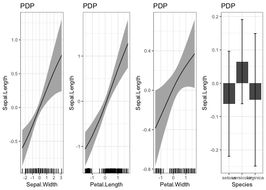

```r
PDP(nn.fit)
```

```r
library(effects)
```

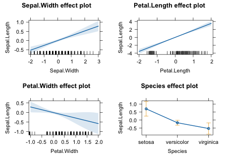

```r
plot(allEffects(lm(Sepal.Length~., data = df)))
```

There are some differences between the statistical model and the NN - which is to be expected because the NN can fit the data more flexible. But at the same time the differences have large confidence intervals (e.g. the effect of Petal.Width)